# PCWG_share_01_main

Andy Clifton

2015-12-01

# Introduction

This document contains the results of the Power Curve Working Group’s Share_01 exercise, which ran from October to December 2015. The document and results are generated using the programing language `R` from the *PCWG_share_01_main.rmd* file and can be run by participants themselves.

## How to use PCWG_share_01_main.rmd

install R (http://www.r-project.org) and Rstudio (http://www.rstudio.com), and then create a directory with all of the code and files (see below). When you click the **Knit** button in RStudio a document will be generated that includes text and results from the code embedded in *PCWG_share_01_main.rmd*.

## User Inputs

The *project.root* variable defines the location of the files required for this analysis. The *made.by* variable forms part of a label that will be added to the plots. *data.public* is a flag that indicates whether the results of the analysis are intended to be public, or not. *data.reanalyze* is a flag that indicates whether individual data files should be reanalyzed (*data.reanalyze = TRUE*) or whether saved, aggregated data should be used (*data.reanalyze = FALSE*).

The following user inputs were used in the preparation of this document:

```r
# Where can files be found?
project.root <- file.path('/Users/aclifton/Documents/confidential/projects/PCWG Share 01')

# Who ran this script
made.by = "A. Clifton, NREL"

# Will data be public or not?
data.public = TRUE

# Reanalyze existing data?
data.reanalyze = FALSE
```

This document was produced from data saved at /Users/aclifton/Documents/confidential/projects/PCWG Share 01/analysis/all/AggregatedData.RData

## Directory structure

The folowing files should be placed in the *project.root* directory:

- PCWG_share_01_main.Rmd
- /**analysis** directory containg results of the analysis
- /**code** directory containing functions required for the analysis
- /**data** directory containing all data files to be analyzed. This can include further sub directories. All .xls files contained in **data** and sub directories will be used in the analysis.

## Packages

This script requires the *ggplot2*, *grid*, *knitr*, *RColorBrewer*, *rgdal*, and *XLConnect* packages to run. These are called from the script but you may need to install them directly. For details of how to install packages, see the RStudio help.

# Results from each data set

We now analyse the data from each data set. The plots are saved to their own directories in the *analysis* directory. If *data.public* is FALSE, plots will be created for every data set. If *data.public* is TRUE, only the final, aggregated data plots will be created.

# Aggregated Data Sets

In this section, data from all of the individual submissions have been combined.

## Turbine Sizes

In total, 52 data sets were submitted. The 52 data sets include tests carried out in the period from 2009 to 2015. Turbine diameters range from 50 to 130 m, while hub heights range from 44 to 120 m.

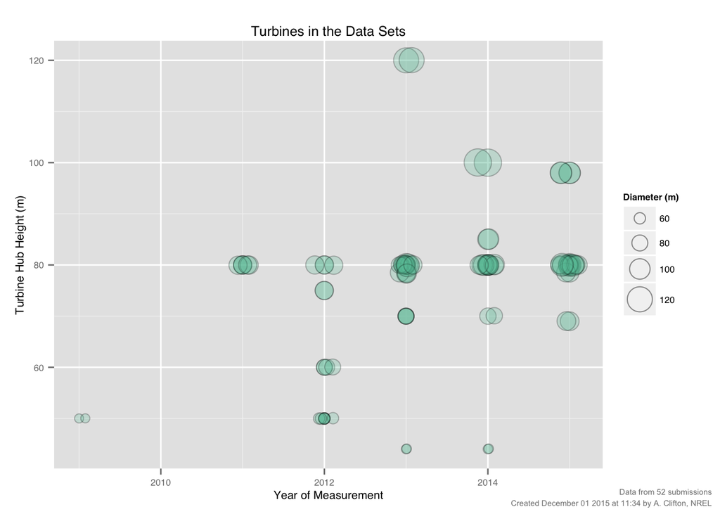

## Turbine Locations

The coutry in which the turbine was located was reported in 35 of the data sets.

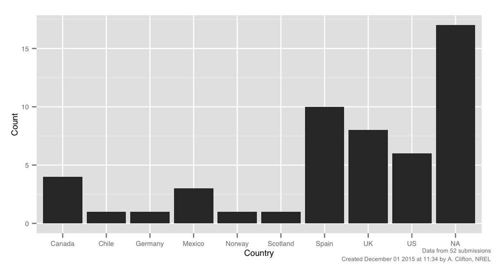

Data were obtained from turbines in 9 countries including US, Canada, UK, Germany, Mexico, Spain, Chile, Scotland, and Norway.

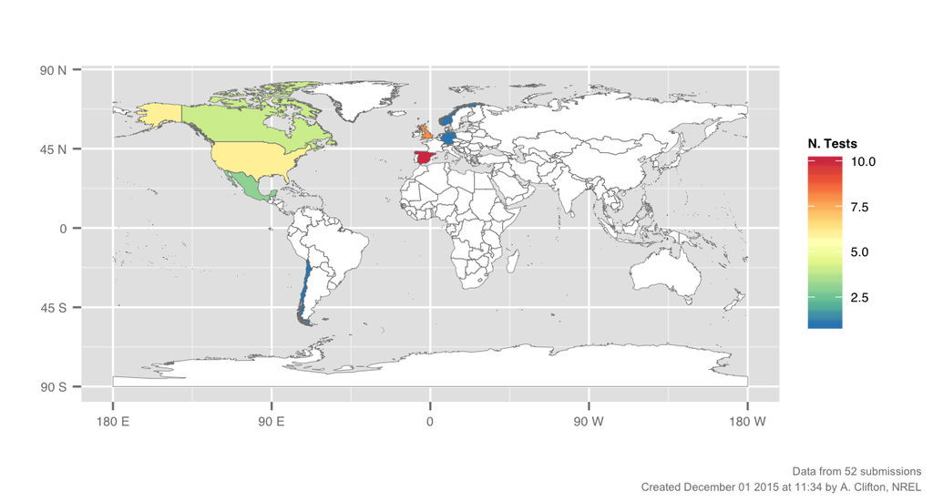

# Results from Each Data Set

## Errors versus wind speed for all submissions

- The baseline method
- The rotor-equivalent wind speed method (REWS)
- The turbulence correction method
- The turbulence correction method using REWS wind speeds, and
- The power deviation matrix.

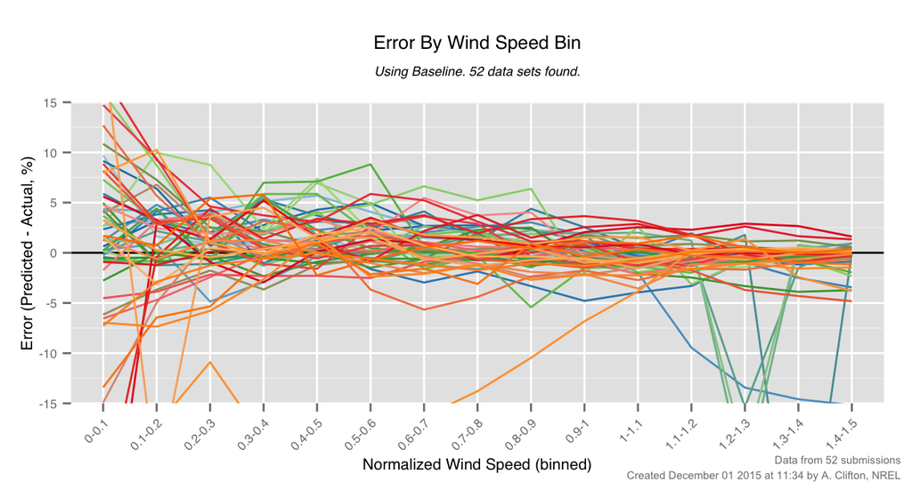

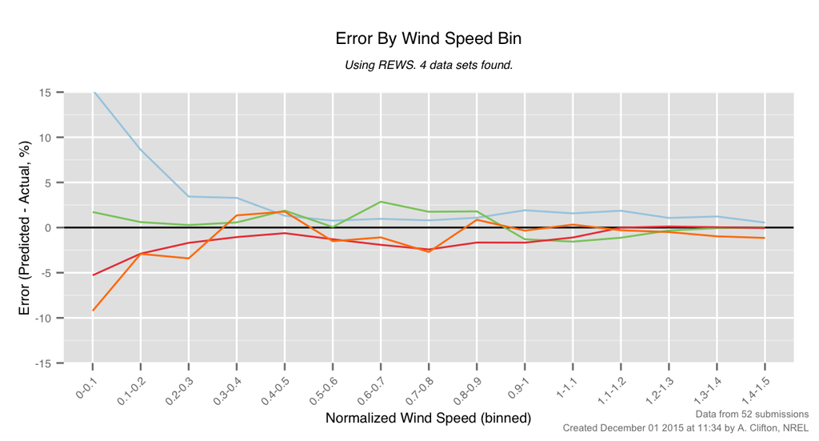

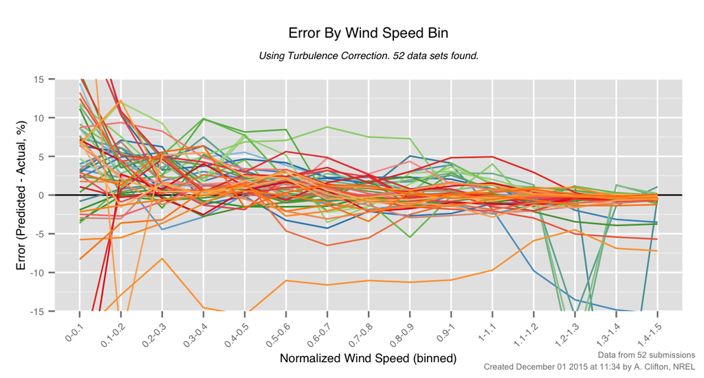

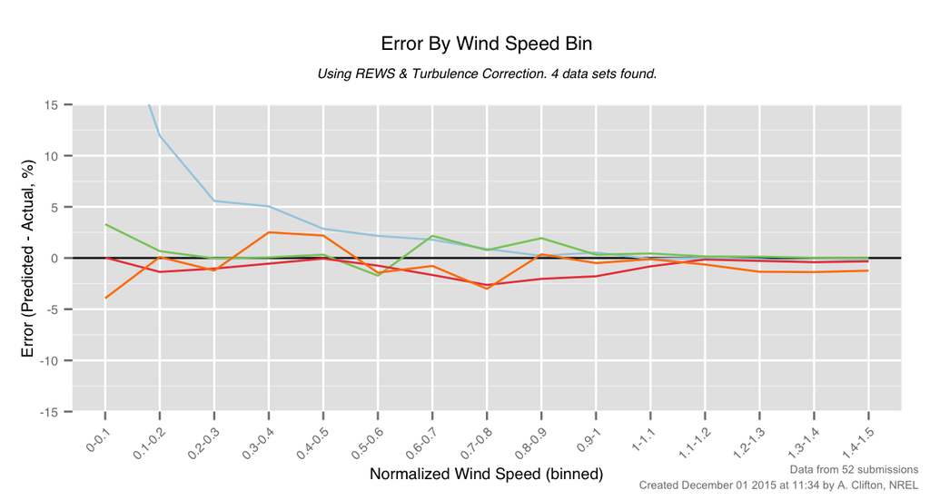

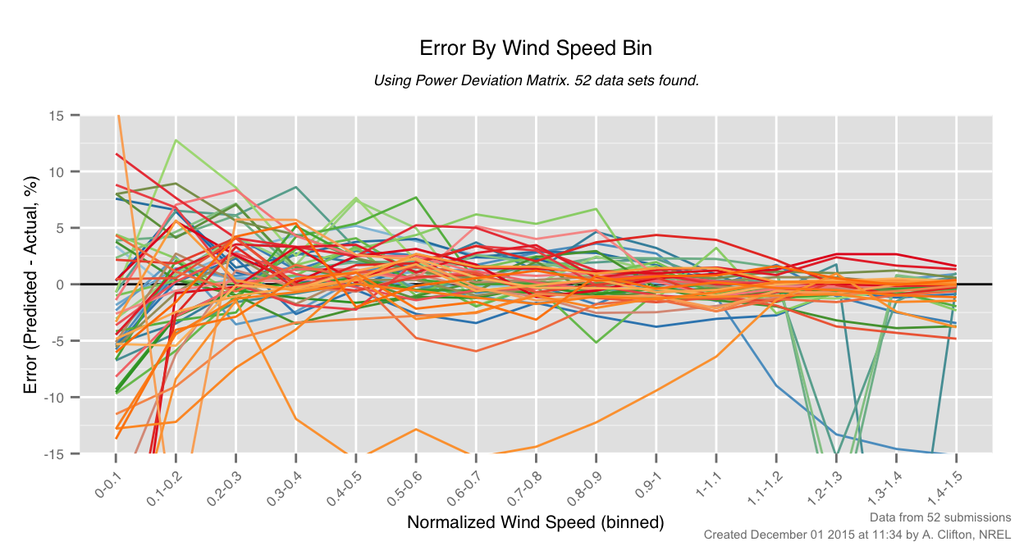

## Errors Binned by Wind Speed

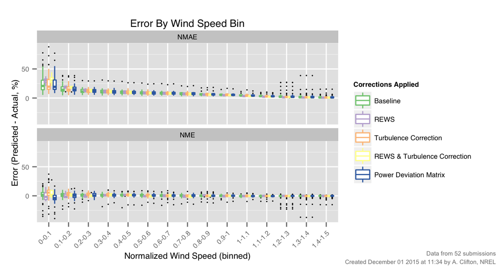

## Change in errors binned by Wind Speed

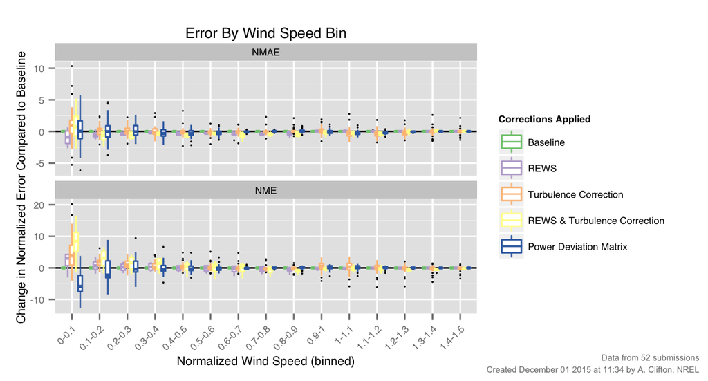

# Aggregated results

In this section, data from all of the individual data sets have been combined.

## Baseline Inner and Outer Range Error Histograms

The inner and outer range are defined in the PCWG’s 2013 Proposal (see http://www.pcwg.org/proposals/PCWG-Inner-Outer-Range-Proposal-Dec-2013.pdf) as:

- **The Inner Range**: the range of conditions for which one can expect to achieve an Annual Energy Production (AEP) of 100% (relative to a reference power curve).
- **The Outer Range**: the range of conditions for which one can expect to achieve an AEP of less than 100%. Stated another way the outer range is the range of all possible conditions excluding those in the inner range.

Based on this definition, it would be expected that the error in the inner range would be less than the error in the outer range. This expectation is supported by the following figure.

[figure not shown]

## The Effect of The Turbulence Correction on the Outer Range Error

The PCWG investigated the effect of turbulence on the power curve uncertainty. The effect of turbulence was to be accounted for using the turbulence correction approach. If this approach were succesful, we would expect to see reduced error with the turbulence correction, compared to the baseline. A comparison of the outer range error with and without turbulence correction is shown in the following figure.

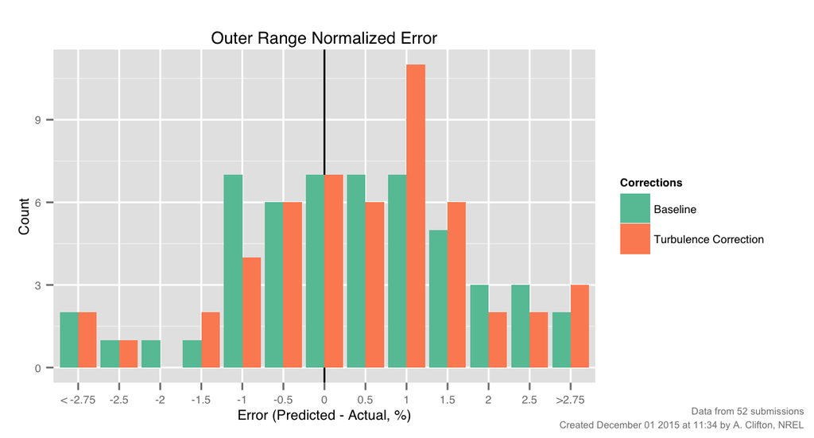

# The Effect of Other Corrections

A similar analysis as in the previous section can be applied to the improvement in both the inner and outer range. The following plot shows the difference in the error in each data set in the inner or outer range, compared to the baseline method. The 1:1 line is shown for comparison; a data point below the line has a lower normalized mean error with the correction, than it had with the baseline method. The number of data sets with each correction is also shown, together with the percentage of the data sets that showed an improvement using this correction.

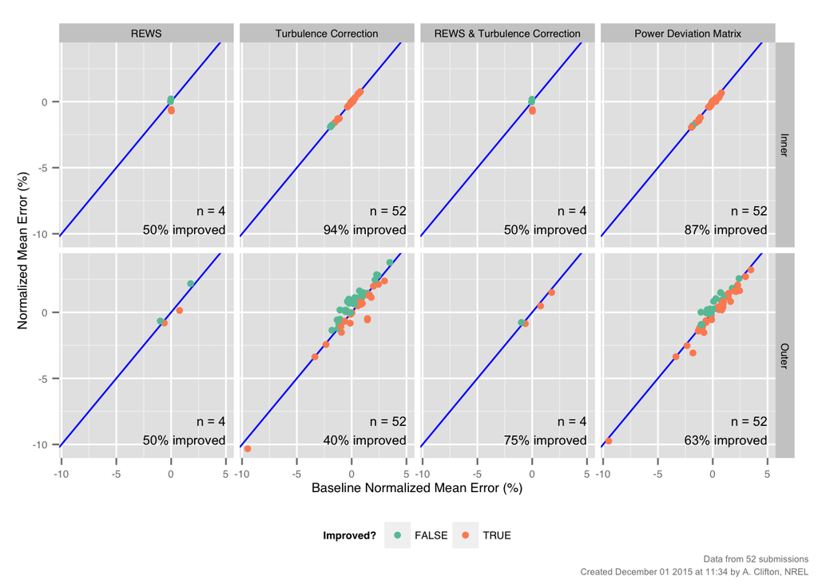

```r
PlotImprovementByRangeAndCorrection(all.data$errors$by.Range,
                                    plot.label,
                                    output.dir)
```

## Errors Binned by Wind Speed and Ti

The following plot shows how effective each set of corrections is, for each of four combinations of wind speed and turbulence intensity. Data are plotted with respect to the baseline case for that combination, such that a positive change indicates an increase in error, and a negative change indicates a decrease in error.

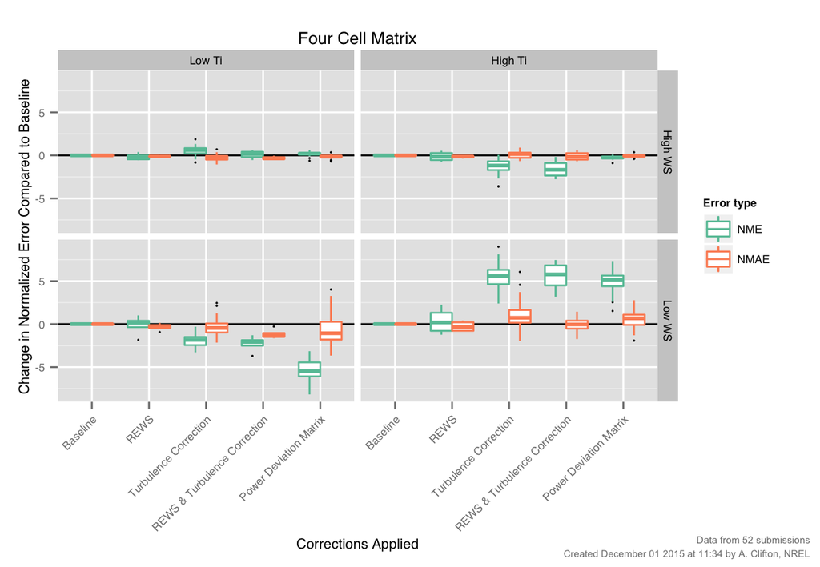